# Which chemical properties influence the quality of white wines?

Serhii Vykaliuk

# Introduction

This report explores a dataset white wines. This tidy dataset contains 4, 898 white wines with 11 variables on quantifying the chemical properties of each wine. At least three wine experts rated the quality of each wine, providing a rating between 0 (very bad) and 10 (very excellent).

This dataset is publicly available for research. The details are described in (Cortez et al. 2009).

```
## 'data.frame':    4898 obs. of  12 variables:
##  $ fixed.acidity       : num  7 6.3 8.1 7.2 7.2 8.1 6.2 7 6.3 8.1 ...
##  $ volatile.acidity    : num  0.27 0.3 0.28 0.23 0.23 0.28 0.32 0.27 0.3 0.22 ...
##  $ citric.acid         : num  0.36 0.34 0.4 0.32 0.32 0.4 0.16 0.36 0.34 0.43 ...
##  $ residual.sugar      : num  20.7 1.6 6.9 8.5 8.5 6.9 7 20.7 1.6 1.5 ...
##  $ chlorides           : num  0.045 0.049 0.05 0.058 0.058 0.05 0.045 0.045 0.049 0.044 ...
##  $ free.sulfur.dioxide : num  45 14 30 47 47 30 30 45 14 28 ...
##  $ total.sulfur.dioxide: num  170 132 97 186 186 97 136 170 132 129 ...
##  $ density             : num  1.001 0.994 0.995 0.996 0.996 ...
##  $ pH                  : num  3 3.3 3.26 3.19 3.19 3.26 3.18 3 3.3 3.22 ...
##  $ sulphates           : num  0.45 0.49 0.44 0.4 0.4 0.44 0.47 0.45 0.49 0.45 ...
##  $ alcohol             : num  8.8 9.5 10.1 9.9 9.9 10.1 9.6 8.8 9.5 11 ...
##  $ quality             : int  6 6 6 6 6 6 6 6 6 6 ...
```

Variable quality is an integer, and all other 11 variables are the float.

Input variables (based on physicochemical tests):

1. fixed acidity (tartaric acid - g/dm<sup>3</sup>)
2. volatile acidity (acetic acid - g/dm<sup>3</sup>)
3. citric acid (g/dm<sup>3</sup>)
4. residual sugar (g/dm<sup>3</sup>)
5. chlorides (sodium chloride - g/dm<sup>3</sup>)
6. free sulfur dioxide (mg/dm<sup>3</sup>)
7. total sulfur dioxide (mg/dm<sup>3</sup>)
8. density (g/cm<sup>3</sup>)
9. pH
10. sulphates (potassium sulphate - g/dm<sup>3</sup>)
11. alcohol (% by volume)

Output variable (based on sensory data):

12. quality (score between 0 and 10)

The `free.sulfur.dioxide` and `total.sulfur.dioxide` measured in units mg/dm<sup>3</sup> and I think I may convert them to g/dm<sup>3</sup> that will lead our variables to one scale.

Summaries of the variables

|  | Min. | 1st Qu. | Median | Mean | 3rd Qu. | Max. |
| --- | --- | --- | --- | --- | --- | --- |
| fixed.acidity | 3.80000 | 6.3000000 | 6.80000 | 6.8547877 | 7.3000 | 14.20000 |
| volatile.acidity | 0.08000 | 0.2100000 | 0.26000 | 0.2782411 | 0.3200 | 1.10000 |
| citric.acid | 0.00000 | 0.2700000 | 0.32000 | 0.3341915 | 0.3900 | 1.66000 |
| residual.sugar | 0.60000 | 1.7000000 | 5.20000 | 6.3914149 | 9.9000 | 65.80000 |
| chlorides | 0.00900 | 0.0360000 | 0.04300 | 0.0457724 | 0.0500 | 0.34600 |
| free.sulfur.dioxide | 2.00000 | 23.0000000 | 34.00000 | 35.3080849 | 46.0000 | 289.00000 |
| total.sulfur.dioxide | 9.00000 | 108.0000000 | 134.00000 | 138.3606574 | 167.0000 | 440.00000 |
| density | 0.98711 | 0.9917225 | 0.99374 | 0.9940274 | 0.9961 | 1.03898 |
| pH | 2.72000 | 3.0900000 | 3.18000 | 3.1882666 | 3.2800 | 3.82000 |
| sulphates | 0.22000 | 0.4100000 | 0.47000 | 0.4898469 | 0.5500 | 1.08000 |
| alcohol | 8.00000 | 9.5000000 | 10.40000 | 10.5142670 | 11.4000 | 14.20000 |
| quality | 3.00000 | 5.0000000 | 6.00000 | 5.8779094 | 6.0000 | 9.00000 |

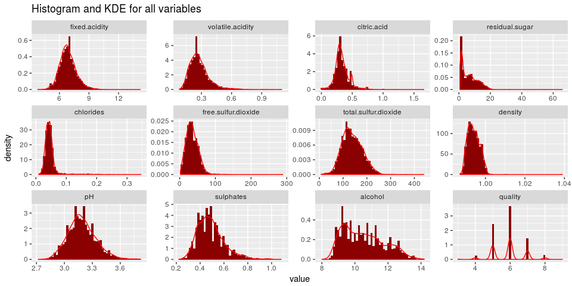

The variables `fixed.acidity`, `volatile.acidity`, `citric.acid`, `residual.sugar`, `chlorides`, `free.sulfur.dioxide`, `total.sulfur.dioxide` and `sulphates` have long rigth tail with many outlets. The source of that is them phisical nature and tools for measure.

# Univariate Plots Section

### Variable `fixed.acidity`

> fixed.acidity (tartaric acid - g/dm<sup>3</sup>) : most acids involved with wine or fixed or nonvolatile (do not evaporate readily)

> – (Cortez et al. 2009)

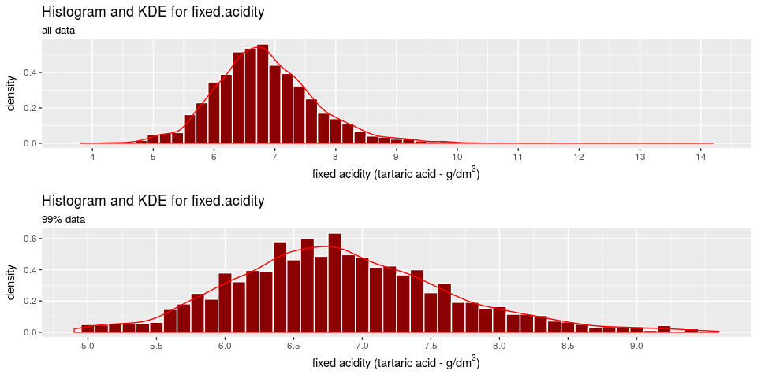

99% wines have a fixed.acidity between 4.9 g/dm<sup>3</sup> and 9.6 g/dm<sup>3</sup> with median 6.8 g/dm<sup>3</sup> and mean 6.855 g/dm<sup>3</sup>.

### Variable `volatile.acidity`

> volatile.acidity (acetic acid - g/dm<sup>3</sup>) : the amount of acetic acid in wine, which at too high of levels can lead to an unpleasant, vinegar taste

> – (Cortez et al. 2009)

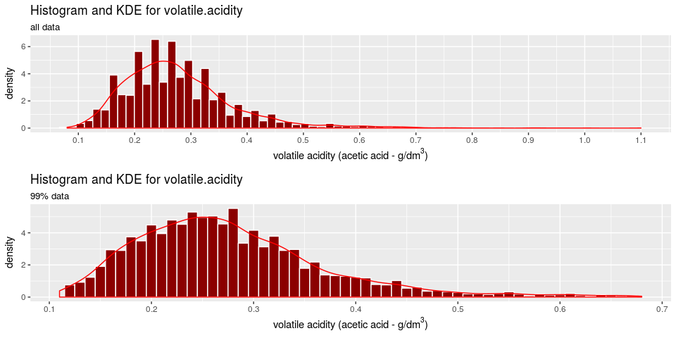

99% wines have a volatile.acidity between 0.11 g/dm<sup>3</sup> and 0.68 g/dm<sup>3</sup> with median 0.26 g/dm<sup>3</sup> and mean 0.278 g/dm<sup>3</sup>.

### Variable `citric.acid`

> citric.acid (g/dm<sup>3</sup>) : found in small quantities, citric acid can add ‘freshness’ and flavor to wines

> – (Cortez et al. 2009)

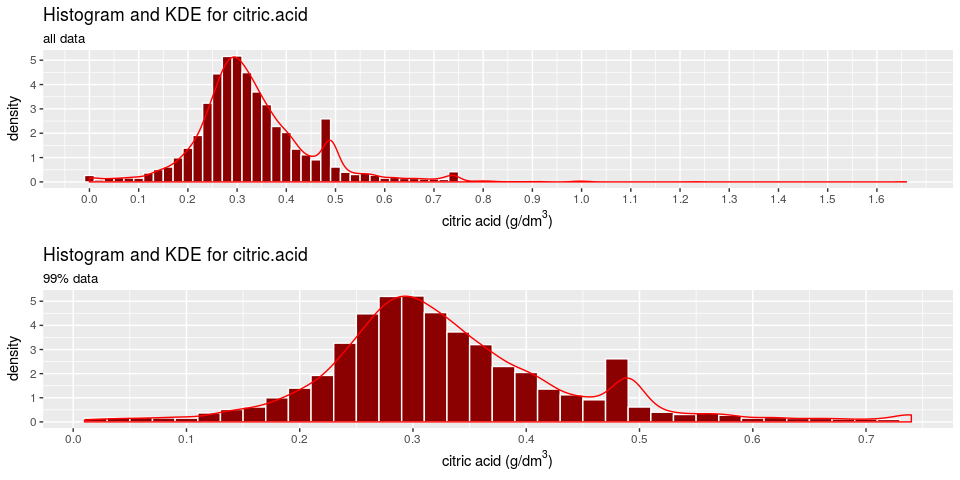

99% wines have a citric.acid between 0.01 g/dm<sup>3</sup> and 0.74 g/dm<sup>3</sup> with median 0.32 g/dm<sup>3</sup> and mean 0.334 g/dm<sup>3</sup>.

We can see two tops in point 0.49 and point 0.74 that may result from a commercial process of produce wine. ([Wikipedia](https://en.wikipedia.org/wiki/Acids_in_wine#Citric_acid))

### Variable `residual.sugar`

> residual.sugar (g/dm<sup>3</sup>) : the amount of sugar remaining after fermentation stops, it’s rare to find wines with less than 1 gram/liter and wines with greater than 45 grams/liter are considered sweet

> – (Cortez et al. 2009)

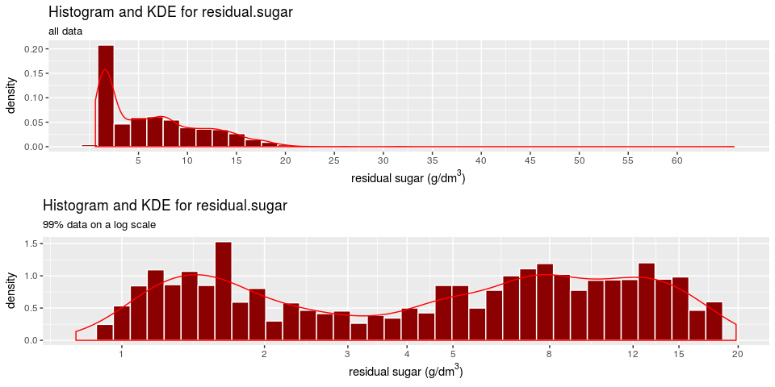

99% wines have a residual.sugar between 0.8 g/dm<sup>3</sup> and 19.8 g/dm<sup>3</sup> with median 5.2 g/dm<sup>3</sup> and mean 6.391 g/dm<sup>3</sup>.

If we transform `residual.sugar` by log10, we can see the bimodal distribution with the peaking near 1.5 and again in segment 8-13.

I created a new variable to classify the wine according to the [sugar content](https://en.wikipedia.org/wiki/Sweetness_of_wine#Terms_used_to_indicate_sweetness_of_wine).

| Labels | Sweetness |
| --- | --- |
| Dry | up to 4 g/l |
| Medium dry | up to 12 g/l |
| Medium | up to 45 g/l |
| Sweet | more than 45 g/l |

I made the variable according to the table above.

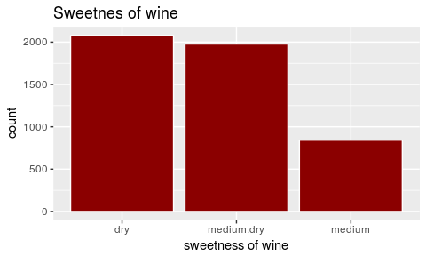

Since in our data, only one sample contains more sugar than 45 g/dm<sup>3</sup>, I divided our collection into three classes.

### Variable `chlorides`

> chlorides (sodium chloride - g/dm<sup>3</sup>) : the amount of salt in the wine

> – (Cortez et al. 2009)

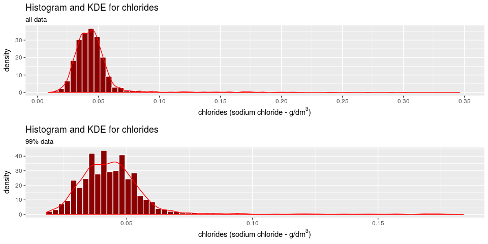

99% wines have a chlorides between 0.018 g/dm<sup>3</sup> and 0.184 g/dm<sup>3</sup> with median 0.043 g/dm<sup>3</sup> and mean 0.046 g/dm<sup>3</sup>.

### Variable `free.sulfur.dioxide`

> free.sulfur.dioxide (mg/dm<sup>3</sup>) : the free form of SO2 exists in equilibrium between molecular SO2 (as a dissolved gas) and bisulfite ion; it prevents microbial growth and the oxidation of wine

> – (Cortez et al. 2009)

I converted the variable `free.sulfur.dioxide` to g/dm<sup>3</sup>.

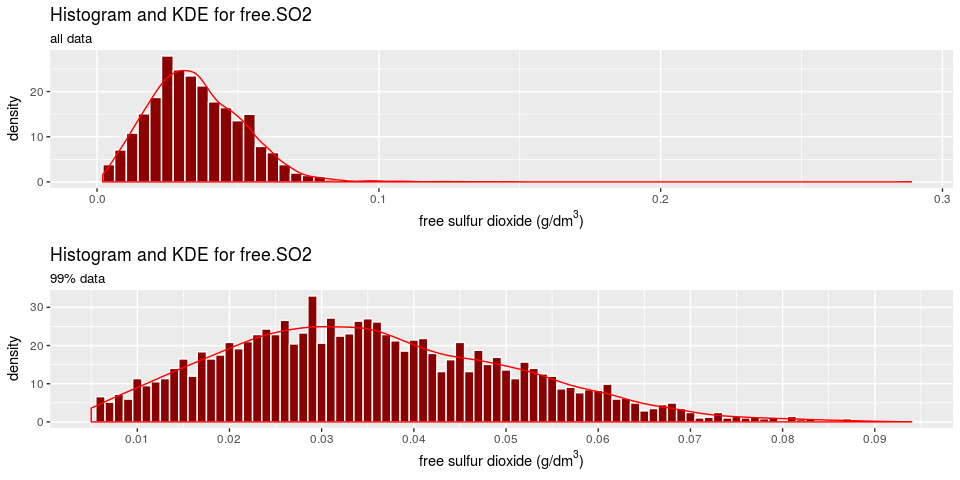

99% wines have a free.SO2 between 0.005 g/dm<sup>3</sup> and 0.094 g/dm<sup>3</sup> with median 0.034 g/dm<sup>3</sup> and mean 0.035 g/dm<sup>3</sup>.

### Variable `total.sulfur.dioxide`

> total.sulfur.dioxide (mg/dm<sup>3</sup>) : amount of free and bound forms of S02; in low concentrations, SO2 is mostly undetectable in wine, but at free SO2 concentrations over 50 ppm, SO2 becomes evident in the nose and taste of wine

> – (Cortez et al. 2009)

I converted the variable `total.sulfur.dioxide` to g/dm3.

This variable contains free and bound forms of S02. The free form we have above and I left only the bound component of SO2.

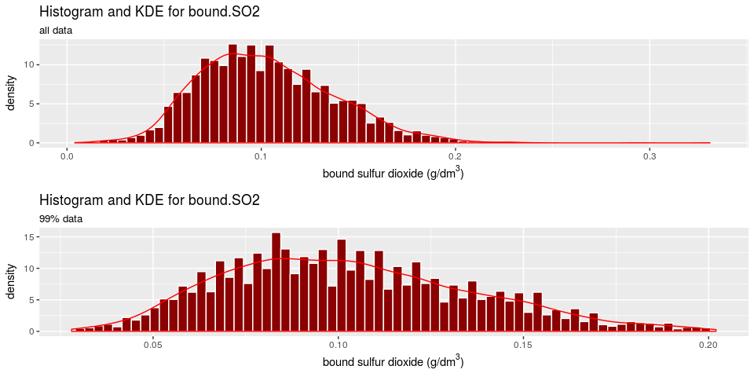

99% wines have a bound.SO2 between 0.028 g/dm<sup>3</sup> and 0.202 g/dm<sup>3</sup> with median 0.1 g/dm<sup>3</sup> and mean 0.103 g/dm<sup>3</sup>.

Since the minimum of the new variable `bound.SO2` is 0.004 > 0 then it means that in each pair `total.sulfur.dioxide - free.sulfur.dioxide > 0` and the transformation is done correctly.

### Variable `density`

> density (g/cm<sup>3</sup>) : the density of water is close to that of water depending on the percent alcohol and sugar content

> – (Cortez et al. 2009)

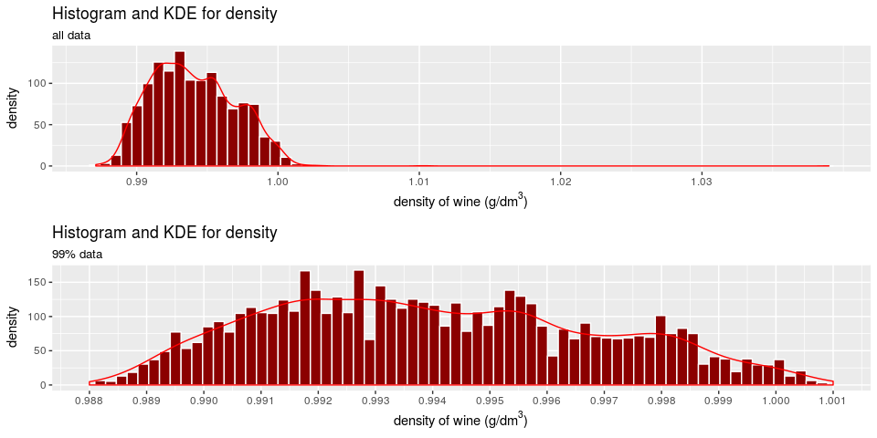

99% wines have a density between 0.988 g/dm<sup>3</sup> and 1.001 g/dm<sup>3</sup> with median 0.994 g/dm<sup>3</sup> and mean 0.994 g/dm<sup>3</sup>.

### Variable `pH`

> pH : describes how acidic or basic a wine is on a scale from 0 (very acidic) to 14 (very basic); most wines are between 3-4 on the pH scale

> – (Cortez et al. 2009)

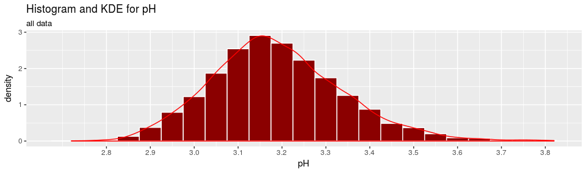

99% wines have a pH between 2.86 g/dm<sup>3</sup> and 3.66 g/dm<sup>3</sup> with median 3.18 g/dm<sup>3</sup> and mean 3.188 g/dm<sup>3</sup>.

Of all the variables considered above, the distribution of `pH` is most similar to the normal distribution.

### Variable `sulphates`

> sulphates (potassium sulphate - g/dm<sup>3</sup>) : a wine additive which can contribute to sulfur dioxide gas (S02) levels, wich acts as an antimicrobial and antioxidant

> – (Cortez et al. 2009)

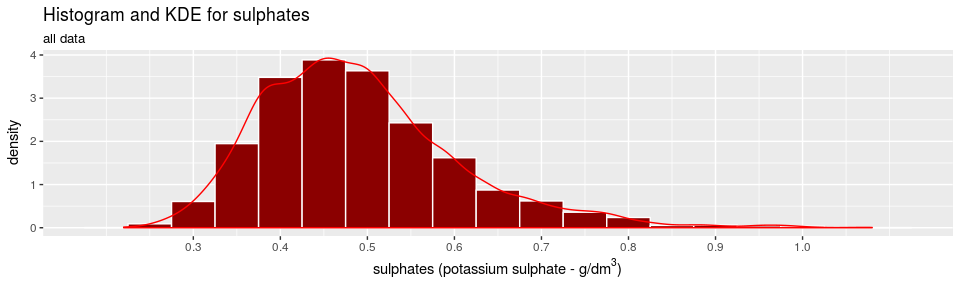

99% wines have a sulphates between 0.28 g/dm<sup>3</sup> and 0.9 g/dm<sup>3</sup> with median 0.47 g/dm<sup>3</sup> and mean 0.49 g/dm<sup>3</sup>.

### Variable `alcohol`

> alcohol (% by volume) : the percent alcohol content of the wine

> – (Cortez et al. 2009)

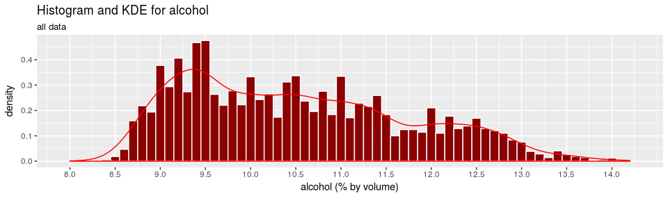

99% wines have a alcohol between 8.6 g/dm<sup>3</sup> and 13.6 g/dm<sup>3</sup> with median 10.4 g/dm<sup>3</sup> and mean 10.514 g/dm<sup>3</sup>.

### Variable `quality`

> quality (score between 0 and 10)

> – (Cortez et al. 2009)

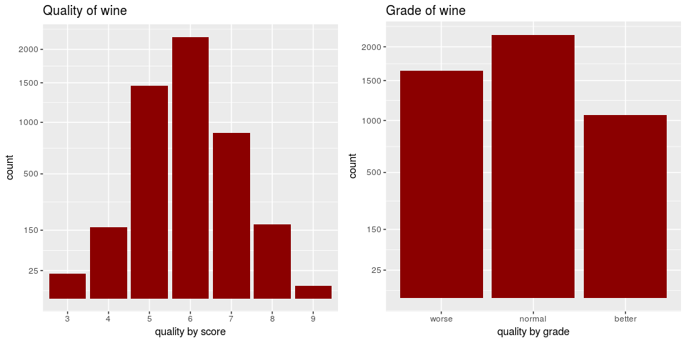

For quality wine, experts used ratings from 3 to 9 (didn’t use 0, 1, 2 and 10). The highest number of wines rated the score number six. I made a new variable “grade” which have three categories. Wines with score six belong to category “normal.” Wines with scores greater than six belong to category “better” and other wines have the category “worse.”

# Univariate Analysis

### What is the structure of your dataset?

The database contains information on white wines and consists of 4898 observation with 12 variables. Only one variable ‘quality’ is ordered factor variable with levels from 3 to 9.

All other variables are physical or chemical characteristics of wine, so they all have a positive floating number. The features `fixed.acidity`, `volatile.acidity`, `citric.acid`, `chlorides`, `free.sulfur.dioxide`, `total.sulfur.dioxide` and `sulphates` have a distribution similar to the normal distribution with a long tail at the right part. Also, we can see the bimodal distribution of `residual.sugar` if we use transform by log10.

### What is/are the main feature(s) of interest in your dataset?

The main feature in the data set is the quality of wine because the main question is which features influence to the quality?

### What other features in the dataset do you think will help support your investigation into your feature(s) of interest?

I think that the `alcohol`, `residual.sugar`, `pH`, and `density` are most influence features in this exploration.

### Did you create any new variables from existing variables in the dataset?

I created two new categorical variable `grade` and `sweetness`. I will use them in next parts of this investigation.

Also, I created two continuous variable `free.SO2` and `bound.SO2` when I transformed `free.sulfur.dioxide` to g/dm<sup>3</sup> and separated bound part from `total.sulfur.dioxide` variable.

### Of the features you investigated, were there any unusual distributions? Did you perform any operations on the data to tidy, adjust, or change the form of the data? If so, why did you do this?

This dataset is tidy, but two variable have some differences. The first, `citric.acid` have two peaks in distribution. The second, the distribution of `residual.sugar` is like distribution of Poisson but transform with logarithm give the ability to see bimodal distribution.

# Bivariate Plots Section

### Correlation plot by Spearman

The nature of dataset variables is physicochemical and so that density tied with the amount alcohol and amount salts and acid, so I think that [correlation of Spearman](http://bit.ly/2i1HztO) is a good choice.

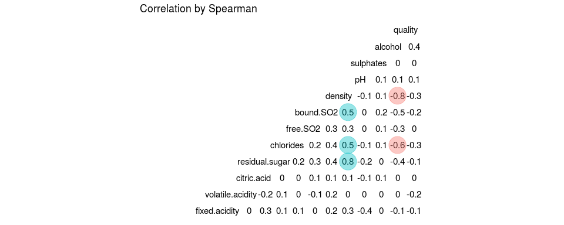

In the first part, I analyze relationship variable `quality` with other features. The second, I analyze variables with absolute correlation more than 0.5.

### Quality vs `density`, `chlorides`, and `bound.SO2`

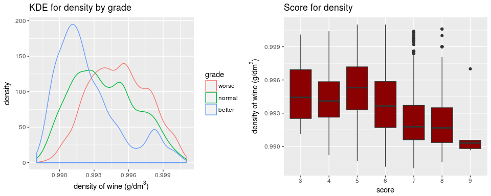

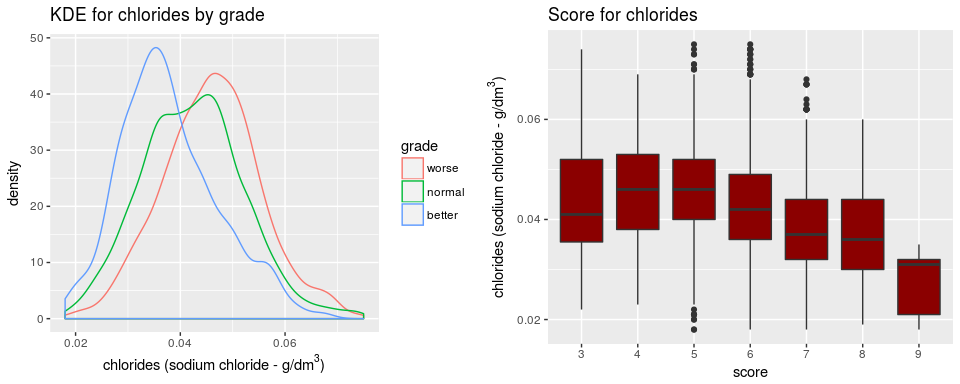

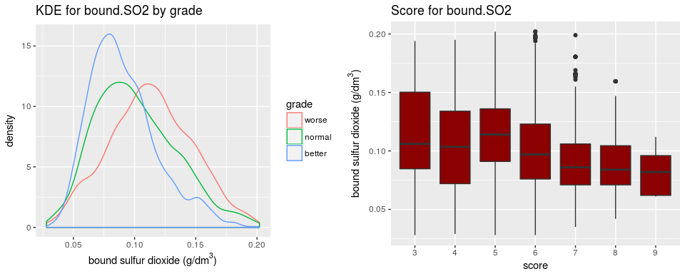

On this three plots, we can see that kernel density have three different tops for different quality of wine and on all box plots for quality more than four the `density`, `chlorides`, and `bound.SO2` decrease for better quality.

### Quality vs `pH` and `alcohol`

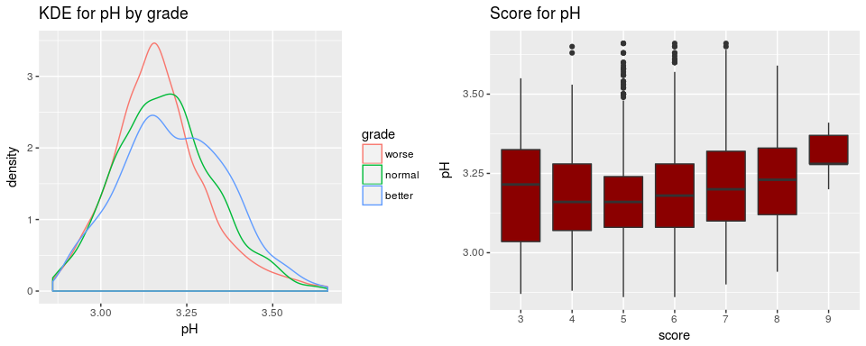

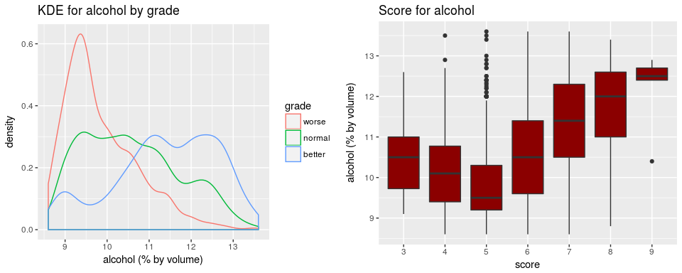

And here the correlation is positive and we can see an increase.

## Jitter plots for variables with correlation > 0.5

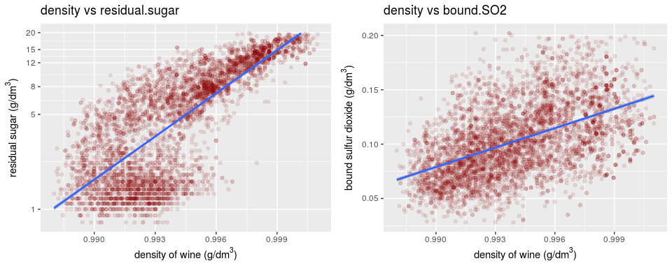

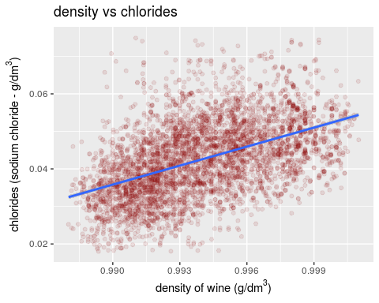

In these plots, we can see a positive correlation between `density` and `residual.sugar`, `bound.SO2`, `chlorides`.

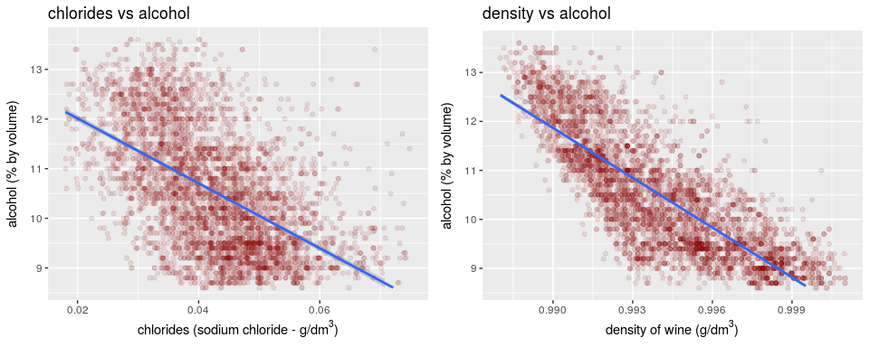

In these plots, we can see a negative correlation between `alcohol` and `density`, `chlorides`.

# Bivariate Analysis

### Talk about some of the relationships you observed in this part of the investigation. How did the feature(s) of interest vary with other features in the dataset?

For a wine that has a quality less than four, the relationships between variables are apparently not followed. But for a quality wine of 5 or more, we can observe the tendency to reduce `density`, `chlorides`, and `bound.SO2` and increase the `pH` and `alcohol` for wine with the best estimates.

### Did you observe any interesting relationships between the other features (not the main feature(s) of interest)?

Unlike the `quality` of a wine, other variables have more prominent relationships with each other. Especially this connection is noticeable between the `density` on one side and `chlorides`, `residual.sugar` and `bound.SO2` on the other side. The `density` of wine increases with the increase in the amount of these substances. But the `density` also depends on `alcohol` and decreases as it grows. A surprise for me was the negative dependence of `alcohol` on `chlorides`.

### What was the strongest relationship you found?

I found two strong correlations between `density` and `residual.sugar` and also between `density` and `alcohol`.

# Multivariate Plots Section

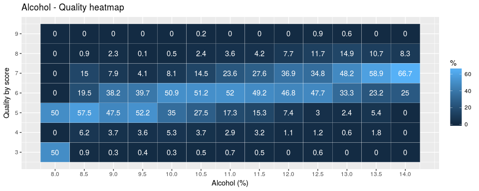

I have collected in this table in each cell only than wines that have the appropriate quality and the corresponding percentage of alcohol. Then I normalized the columns, and the final figures were converted into percentages.

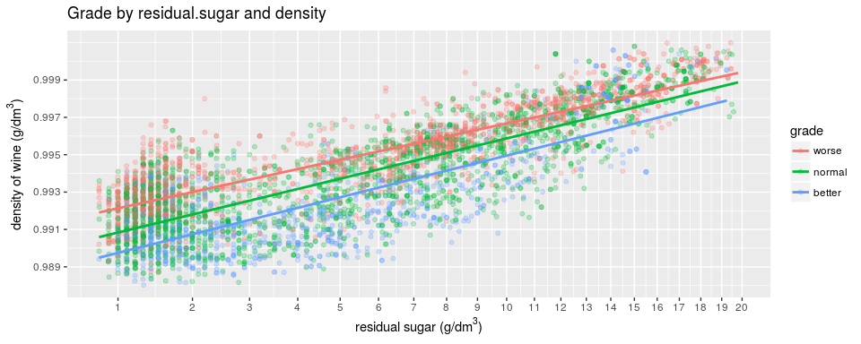

In this plot, we can see how the `quality` of a wine, `density`, and `residual.sugar` are interrelated. For a `density` of 0.989 to 0.998, we see that for the same value of the `density` of wine with a better `grade` contain more `residual.sugar`.

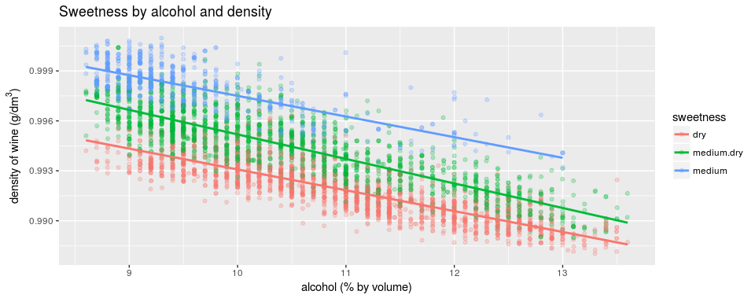

These plots suggest that we can build a classification model and use those variables in our model to predict the quality of the wine. For this, I took the random forest model. I split the dataset into two parts: 70% for train and 30% for a test.

After train our model we can see 32.7% errors.

```
##
## Call:
##  randomForest(formula = score ~ ., data = wine.train)
##                Type of random forest: classification
##                      Number of trees: 500
## No. of variables tried at each split: 3
##
##         OOB estimate of  error rate: 32.7%
## Confusion matrix:
##   3  4   5    6   7  8 9 class.error
## 3 0  0   2   10   1  0 0   1.0000000
## 4 0 17  57   35   1  0 0   0.8454545
## 5 0  7 703  321  11  0 0   0.3253359
## 6 0  2 220 1184  92  2 0   0.2106667
## 7 0  0  14  264 356  3 0   0.4411303
## 8 0  0   0   41  33 47 0   0.6115702
## 9 0  0   0    3   2  0 0   1.0000000
```

On test part we can see 31.6326531% errors.

[output not shown]

# Multivariate Analysis

### Talk about some of the relationships you observed in this part of the investigation. Were there features that strengthened each other in terms of looking at your feature(s) of interest?

At this point, we see that wine `score` is mostly related to `alcohol`. Alcohol, in turn, has a connection with `chlorides` and a strong bond with `density`. `Density` is related to `bound.SO2` and has a high correlation with `residual.sugar`.

In this way, the features most affected by the `quality` of the wine are `alcohol`, `density`, `chlorides`, `residual.sugar`, and `bound.SO2`.

# Final Plots and Summary

### Plot One

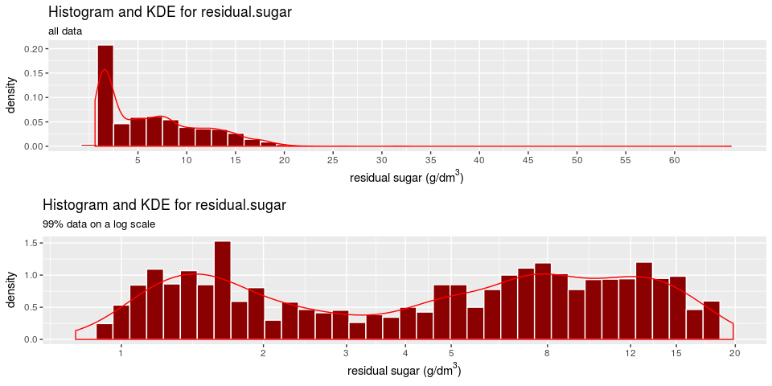

### Description One

If we transform `residual.sugar` by log10, we can see the bimodal distribution with the peaking near 1.5 and again in segment 8-13.

### Plot Two

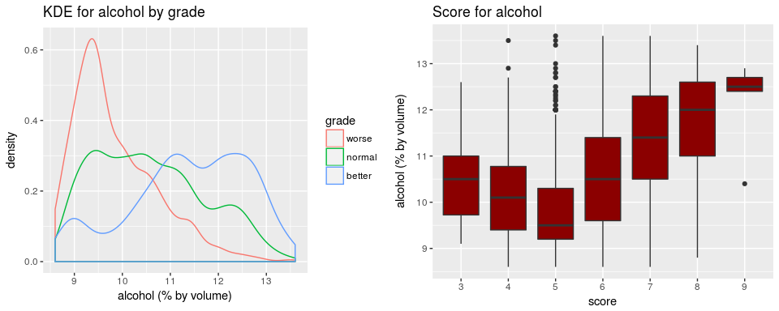

### Description Two

The quality of the wine with low ratings equal three or four is probably influenced by other characteristics, but starting with the assessment 5, the correspondence of higher levels of alcohol to the higher grade of the quality of wine becomes apparent.

### Plot Three

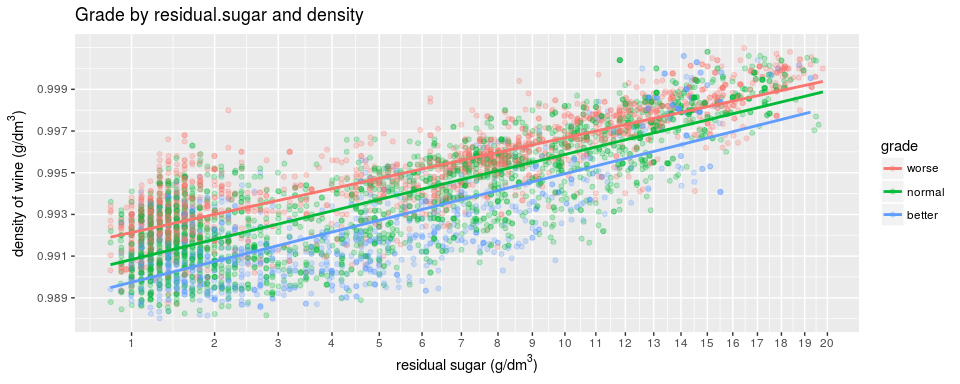

### Description Three

In this plot, we can see how the `quality` of a wine, `density`, and `residual.sugar` are interrelated. For a `density` of 0.989 to 0.998, we see that for the same value of the `density` of wine with a better `grade` contain more `residual.sugar`.

# Reflection

We explore the dataset with the characteristics of white wines. The dataset was in tidy condition and my opinion monotonous.

We have a target variable the `quality` of wine that has a categorical type and the rest of the all variables have continuous types, which led to the uniformity of the charts in the data analysis.

We looked at each variable separately. Variables such as `residual.sugar`, `citric.acid`, `free.sulfur.dioxide`, and `total.sulfur.dioxideand` have attracted our attention more than the rest. Then we constructed a correlation table and examined the relation of our variables in pairs. Next, we investigated relationships between three variables.

By the physicochemical properties of wine, all variables interact with each other as components of one fluid. When one component becomes more or less, the other elements must also be in the corresponding concentrations. Therefore, it is not surprising that the primary variable, which is most closely related to other constituents, was `density`.

Unfortunately, in the description of the data, it is not mentioned anywhere that all the measurements of `density` were made at the same temperature. This fact could have a significant effect on the results, because 99% wines have a density between 0.988 and 1.001 g/dm<sup>3</sup> and it almost coincides with the range of `density` of water change when temperature fluctuations [from 4<sup>о</sup>C to 20<sup>о</sup>C](https://www.engineeringtoolbox.com/water-density-specific-weight-d_595.html).

The expected fact is that `quality` of wine depends on the content of `alcohol`. The surprise was the influence of `chlorides` on the assessment of wine and the amount of `alcohol` in wine.

Adding new variables such as `sweetness` and `grade` allowed drawing more quality pictures. I think that for the further use of these data, the reduction of `free.sulfur.dioxide` and `total.sulfur.dioxideand` to g/dm<sup>3</sup> will have a more significant impact.

I think the next step may be to apply machine learning tools to these data. We can build a classification model. We can test some models and tune parameters for the appropriate model. And the end we can select the best model for predict quality of wine on chemical characteristics.

# Bibliography

Cortez, P., A. Cerdeira, F. Almeida, T. Matos, and J. Reis. 2009. “Modeling wine preferences by data mining from physicochemical properties.” *Decision Support Systems* 47 (4): 547–53.